# Disease Modeling Programming in MATLAB

## Introduction

This MATLAB program is an example of a "Kermack-McKendrick Model" in epidemic modeling.

This is also a good example of

1. Programming in MATLAB
2. Creating a Policy-Relevant Model
3. Illustrating how to code coupled systems of equations.
4. Why you should be getting your flu shot.

The basics of a Kermack-McKendrick Model is that you have [typically] three sub-populations in a community where something icky is going around. This is normally called an "SIR" Model:

1. Susceptibles : people who in principle can get sick (in this case we will bundle a block of people who are immunized into this block)
2. Infected : people who have the disease and can spread it into the Susceptable population
3. Recovered: people who have had the disease and are now immune.

To this category we're adding a "Fatal" category because we are monsters.

Other versions of this system can distribute the Infected category into subgroups that symptomatic (changing their behavior in contrast to the other classes [not including the dead], contagious [at different levels of symptomatic or asymptomatic]).

You can break the "Susceptible" group into those with temporary immunity from their mothers, permanent immunity by random chance, and immunity from immunization.

You can have recovered people who have been infected lose their immunity.

In short, you can let your Pestilence Horseman run wild because “it’s only a model.”

## Sketching the Model Environment and the Kermack-McKendrick Equations

It's always nice to sketch and doodle our models. The black letters will be our variables. (We're not doing the "cordon sanitaire" option (where healthy people wall themselves off from the sick people) in this example.

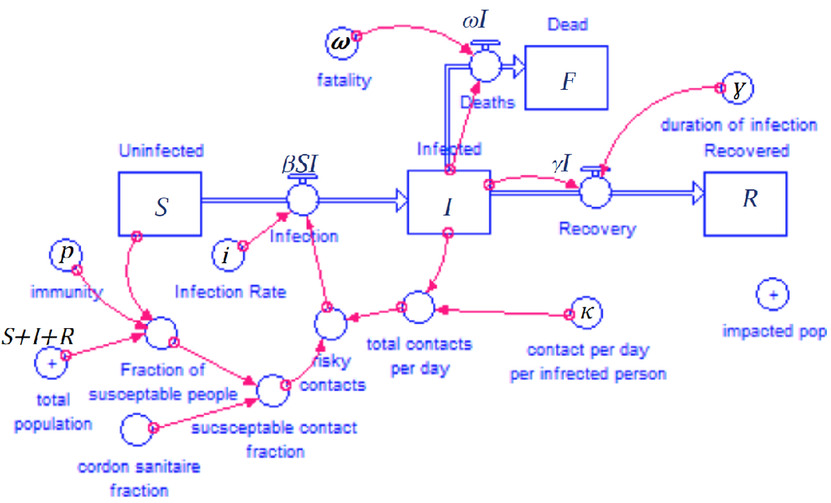

The boxes are our main players from above. The circles are the factors that influence the epidemic. (These become the Left-Hand-Side of our equations.) The red arrows are what connect the factors to what eventually will be what's on the Right-Hand-Side of the equations). Sources and Sinks from our main factors are collected in the blue arrows.

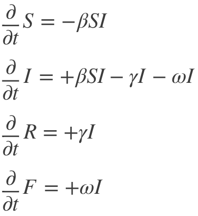

The greek letters above will be explained as we go.

## Setting up the Code

To do this we will break this process down into several sub-sections

1. We will do time control (set up the period of our simulation)
2. We will create the variables for which we will preduct (our Sick, Healthy, Recovered and Dead people)
3. We then will set up the parameters that describe how our disease will behave
4. We will integrate forward in time with a basic Euler’s “solver” for our system of equations.
5. Then plot our output

First let’s set up the time control of our simulation.

## Time Control

This part is easy. We just put together our time steps and the duration of the scenario.

```matlab
%%%%%%%%%%%%%%%%%%%%%%%%%%%%%%%%%%%%%%%%%%%%%%%%%%%%%%%%%%%%%%%%%%%%%%%%%%%
%
% Time Control
%

delta_t =   0.01;    % delta_t in days
time_0 =    0.00;    % time_0 and time_f are start and end days
time_f =   90.00;    %   for this case we are playing the "short game"

% Calculating Basic Time Variables

nt     = (time_f - time_0) / delta_t  + 1; % number of time steps
time   = time_0:delta_t:time_f;            % time in days array created

%
%%%%%%%%%%%%%%%%%%%%%%%%%%%%%%%%%%%%%%%%%%%%%%%%%%%%%%%%%%%%%%%%%%%%%%%%%%%
```

## Population Demographics

With our time set up we can now create a set of “players” in this game

- Susceptables (people who have not acquired the illness)
- Infected (people who have acquired the illness and in this scenario are showing symptions AND are contagious)
- Recovered (people who have recovered from the illness and are no longer infectious)
- Fatalities (people who had the illness but are no longer breathing or doing much of anything else)

And we'll start with 5000 players with one of them returning from Spring Break with... ok that's for later.

```matlab
%%%%%%%%%%%%%%%%%%%%%%%%%%%%%%%%%%%%%%%%%%%%%%%%%%%%%%%%%%%%%%%%%%%%%%%%%%%
%
% Population Initializations
%

S0  = 4999;    % initial susceptible (healthy) cases
I0  =    1;    % initial infected cases
R0  =    0;    % initial recovered (immune) cases
F0  =    0;    % inital fatal cases

%
%%%%%%%%%%%%%%%%%%%%%%%%%%%%%%%%%%%%%%%%%%%%%%%%%%%%%%%%%%%%%%%%%%%%%%%%%%%
```

## #We'reDoingShots!

In this case we can play with a fraction of the population that enter the game with either natural immunity or have been immunized.

You acutally can calculate the threshold immunity (heard immunity) of where a disease will not spread through the community.

```matlab
%%%%%%%%%%%%%%%%%%%%%%%%%%%%%%%%%%%%%%%%%%%%%%%%%%%%%%%%%%%%%%%%%%%%%%%%%%%
%
% Immunization Program
%

initial_fraction_of_population_immunized = 0.00; % fraction of population immunized (0-1)

%
%%%%%%%%%%%%%%%%%%%%%%%%%%%%%%%%%%%%%%%%%%%%%%%%%%%%%%%%%%%%%%%%%%%%%%%%%%%
```

## Disease Traits

Beta from the above equation system is a little more complex than the original case and is a combination of several of these terms.

If we want to include factors like artificial or natural immunity (p) we can include that, too. You can get this through some unit analysis.

```matlab
%%%%%%%%%%%%%%%%%%%%%%%%%%%%%%%%%%%%%%%%%%%%%%%%%%%%%%%%%%%%%%%%%%%%%%%%%%%
%
% Disease Characteristics
%

contact_rate   = 6.00; % typical number of contacts (exposure) per case per day
infection_rate = 0.25; % probabilty of infection on exposure per case per day
fatality_rate  = 0.10; % mean chance of fatality per case per day
recovery_rate  = 0.50; % mean chance of recovery per day per case per day

%
%%%%%%%%%%%%%%%%%%%%%%%%%%%%%%%%%%%%%%%%%%%%%%%%%%%%%%%%%%%%%%%%%%%%%%%%%%%
```

## Value-added Parameters

If you ever saw the medical thriller "Contagion" the [CDC Epidemiologist played by Kate Winslet gives a description of something called the "R-nought" (or Ro) factor while plague-splaining public health metrics to city planners](https://www.youtube.com/watch?v=VrATMF_FB9M) (see the link).

You can get this by borrowing from the various disease traits and doing some unit analysis.

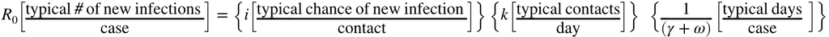

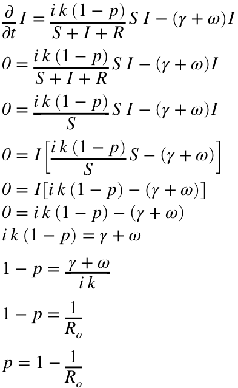

```matlab
%%%%%%%%%%%%%%%%%%%%%%%%%%%%%%%%%%%%%%%%%%%%%%%%%%%%%%%%%%%%%%%%%%%%%%%%%%%
%
% Basic Repoduction Rate (Ro), the one they talk about in movies
%    number of people infected from a single case
%    Ro < 1 the disease will quickly die out and be localized
%    Ro = 1 the disease will hover in a population but should not grow
%    Ro > 1 the disease will spread through the population

Ro = infection_rate * contact_rate / (recovery_rate+fatality_rate);

%
% Critical Herd Immunity, Po, the fraction of the population that must
%   be naturally or artifically immune so that Ro drops below 1 and the
%   disease dies out.  With this closed population case this can happen
%   before the disease reaches everyone in the population.

Po = max(0, 1-1/Ro);     % critical herd immunity (fraction, 0-1)

%
%%%%%%%%%%%%%%%%%%%%%%%%%%%%%%%%%%%%%%%%%%%%%%%%%%%%%%%%%%%%%%%%%%%%%%%%%%%
```

## Starting the Actual Code...

This first section is just doing basic diagnostic print-outs. Like I said most "notebook" type formats such as MATLAB's live scripts could use some improvement. My approach is now to string a very long string of a block of text output and use the newline function in MATLAB to break the lines up.

```matlab
%%%%%%%%%%%%%%%%%%%%%%%%%%%%%%%%%%%%%%%%%%%%%%%%%%%%%%%%%%%%%%%%%%%%%%%%%%%
%
% Print Initial State
%
%   I am not fond of doing print output in MATLAB but this works for me.
%     You "bracket" what you want to say in little strings.  When you need
%     to print a number, wrap it up in a num2str() function.
%

disp(['          Contact Rate : ',num2str(contact_rate),' contacts per infected people per day ',     newline ...
      '         Infecton Rate : ',num2str(infection_rate),' new cases per exposure per day',          newline ...
      '         Fatality Rate : ',num2str(fatality_rate),' mean chance of fatality per case per day', newline ...
      '         Recovery Rate : ',num2str(recovery_rate),' mean chance of recovery per case per day', newline ...
      newline, ...
      'Basic Reproduction Rate (Ro) : ',num2str(Ro),' new infections per infected case',              newline ...
      '     Actual Percent Immunity : ',num2str((initial_fraction_of_population_immunized*100.)),'%', newline ...
      '      Critical Herd Immunity : ',num2str(Po*100.),'%',                                         newline ...
      ' ']);
```

Contact Rate : 6 contacts per infected people per day  
Infecton Rate : 0.25 new cases per exposure per day  
Fatality Rate : 0.1 mean chance of fatality per case per day  
Recovery Rate : 0.5 mean chance of recovery per case per day  
Basic Reproduction Rate (Ro) : 2.5 new infections per infected case  
Actual Percent Immunity : 0%  
Critical Herd Immunity : 60%

```matlab
%
%%%%%%%%%%%%%%%%%%%%%%%%%%%%%%%%%%%%%%%%%%%%%%%%%%%%%%%%%%%%%%%%%%%%%%%%%%%
```

Now let's make the population. Here we "borrow" the time variable from above (because I'm fine with maximum satisfaction with minimal effort) and create a set of "zero" arrays by multiplying time by zero.

Then I am just setting the first index (and MATLAB starts indexing at "1") to our initial number of players on each team from above.

```matlab
%%%%%%%%%%%%%%%%%%%%%%%%%%%%%%%%%%%%%%%%%%%%%%%%%%%%%%%%%%%%%%%%%%%%%%%%%%%
%
% Create Demographic State Variables (i.e., the people)
%
% I'm using a lazy trick here by basically using the time variable
%   we made above to serve as the backbone by which we can make the
%   other variables (we're just multiplying them by zero).
%

S = time * 0; % susceptible cases array created ("cloned" from time)
I = time * 0; % infected cases array created
R = time * 0; % recovered cases array created
F = time * 0; % fatal cases array created

%
% Initiaize Demographic State Variables (i.e., the people)
%

S(1) = S0; % susceptible cases initialized
I(1) = I0; % infected cases initialized
R(1) = R0; % recovered cases initialized
F(1) = F0; % fatal cases initialized

%
%%%%%%%%%%%%%%%%%%%%%%%%%%%%%%%%%%%%%%%%%%%%%%%%%%%%%%%%%%%%%%%%%%%%%%%%%%%
```

## And Away We Go! (Marching through Time)

Now it's time to march forward in time.

We are coding with Euler's Method (a cheap way to march forward in time from Differential Equations but requires tiny time steps).

Euler's Method works thusly.

Let's take just one of our equations, the S, equation.

If we use a Taylor Series and chop off anything above our first-order terms we get a system that looks like this.

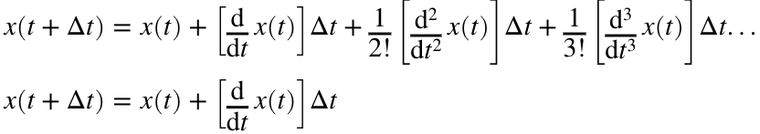

thus...

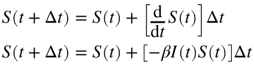

We sometimes call this equation and the part of the modeling program that contains it "The Solver"

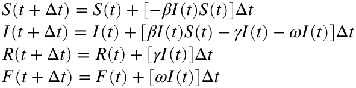

```matlab
%%%%%%%%%%%%%%%%%%%%%%%%%%%%%%%%%%%%%%%%%%%%%%%%%%%%%%%%%%%%%%%%%%%%%%%%%%%
%
% Integrate using a simple Euler's Method approach like we did in class
%

for k = 2:nt  % we already have time step [#1]!

    % calculating critical fields for Kermack-McKendrick Theory

    % we could use these later but we're just collecting the dots here
    %   from the above cartoon that showed the entire system.

    total_people = S(k-1) + I(k-1) + R(k-1);  % calculated here in case
                                              % we expand to having
                                              % births and deaths
                                              % should we want to turn
                                              % our short game to a long
                                              % game

    fraciton_of_susceptable_healthy = S(k-1) / total_people;

    total_infected_contacts_per_day  = I(k-1) * contact_rate;

    exposures_per_day  = fraciton_of_susceptable_healthy * total_infected_contacts_per_day;

    % creating the simple Kermack-McKendrick Theory coefficients;

    % note: beta normally does not include immunity rates.  they go
    %       into another population group but we are keeping it in the
    %       main equations

    P       = initial_fraction_of_population_immunized;

    beta    = infection_rate * contact_rate * (1-P);

    N       = total_people;

    gamma   = recovery_rate;

    omega   = fatality_rate;

    %  Solving the  K-McK equations in derivative form

    dSdt = -(beta/N) * S(k-1) * I(k-1);
    dIdt =  (beta/N) * S(k-1) * I(k-1) - (gamma + omega) * I(k-1);
    dRdt =  gamma    * I(k-1);
    dFdt =  omega    * I(k-1);

    % Euler's Method (First-Order Runge-Kutta) Solver

    S(k) = S(k-1) + dSdt * delta_t;
    I(k) = I(k-1) + dIdt * delta_t;
    R(k) = R(k-1) + dRdt * delta_t;
    F(k) = F(k-1) + dFdt * delta_t;

    % "Floor Control" keeping the result from ever falling below zero,
    %    becaue while you can have negtative personalities, you can't
    %    have negative people

    S(k) = max(0, S(k));
    I(k) = max(0, I(k));
    R(k) = max(0, R(k));
    F(k) = max(0, F(k));

end

%
%%%%%%%%%%%%%%%%%%%%%%%%%%%%%%%%%%%%%%%%%%%%%%%%%%%%%%%%%%%%%%%%%%%%%%%%%%%
```

And then we can include ["The Drive-In Totals"](https://youtu.be/XI2vNyBV_zY?t=144)

```matlab
%%%%%%%%%%%%%%%%%%%%%%%%%%%%%%%%%%%%%%%%%%%%%%%%%%%%%%%%%%%%%%%%%%%%%%%%%%%
%
% Printing final numbers

disp(['      Final Numbers at Time : ',num2str(time_f),' days ', newline ...
      '      Susceptable (Healthy) : ',num2str(S(nt)),           newline ...
      '                   Infected : ',num2str(I(nt)),           newline ...
      '                 Fatalities : ',num2str(F(nt)),           newline ...
      ' Recovered (Aquired Immune) : ',num2str(R(nt))]);
```

Final Numbers at Time : 90 days  
Susceptable (Healthy) : 413.8039  
Infected : 4.7561e-13  
Fatalities : 764.366  
Recovered (Aquired Immune) : 3821.8301

```matlab
%
%%%%%%%%%%%%%%%%%%%%%%%%%%%%%%%%%%%%%%%%%%%%%%%%%%%%%%%%%%%%%%%%%%%%%%%%%%%
```

Or you can plot it up.

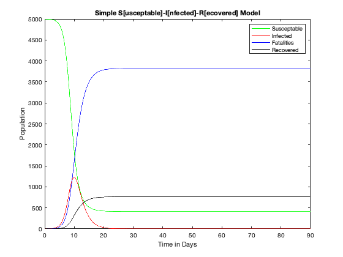

```matlab
%%%%%%%%%%%%%%%%%%%%%%%%%%%%%%%%%%%%%%%%%%%%%%%%%%%%%%%%%%%%%%%%%%%%%%%%%%%
%
% Plotting it up is another way to do it...

% that first "figure()" command makes the background color white and gives
%     the graph window a title

figure('Name',  'SIR Model Plot', ...  % that elispis lets you continue
       'Color', 'white')               % a single command on more than one
                                       % line.  Useful when you want to make
                                       % things look pretty or if you just
                                       % have a lot to do in a single
                                       % line command

plot(time, S, "g-", ...
     time, I, "r-", ...
     time, R, "b-", ...
     time, F, "k-");

xlabel('Time in Days');
ylabel('Population');
title('Simple S[usceptable]-I[nfected]-R[ecovered] Model');
legend('Susceptable', ...
       'Infected',    ...
       'Fatalities',  ...
       'Recovered');
```

```matlab
%%%%%%%%%%%%%%%%%%%%%%%%%%%%%%%%%%%%%%%%%%%%%%%%%%%%%%%%%%%%%%%%%%%%%%%%%%%
%
% End of Program
%
%%%%%%%%%%%%%%%%%%%%%%%%%%%%%%%%%%%%%%%%%%%%%%%%%%%%%%%%%%%%%%%%%%%%%%%%%%%
```

And that's it!

## Not quite the end. Ensemble for Herd Immunity

Before officially closing, let's try one more thing. Let's redo the above modeling exercise but this time, we rerun the model... but we will wrap what we had before in an outer loop -- this one rotating over various immunization rates.

To do this let's create a range of immunity rates from 0 to 1. We will also clone this value to represent the number of players at the end of our game. Instead of plotting our players against time, we'll plot them by the immunity rate.

```matlab
%%%%%%%%%%%%%%%%%%%%%%%%%%%%%%%%%%%%%%%%%%%%%%%%%%%%%%%%%%%%%%%%%%%%%%%%%%%
%
% Second Version Looping Though Immunity Rates
%

% Immunity Rate Values for Loop

immunity_rates = 0 : 0.01 : 1.00;

% as before, we are cloning our final values of players
% against the immunity rates

S_final = immunity_rates * 0.00;
I_final = immunity_rates * 0.00;
R_final = immunity_rates * 0.00;
F_final = immunity_rates * 0.00;

for m = 1:1:numel(immunity_rates) % immunity rates

    for k = 2:nt  % we already have time step [#1]!

        % calculating critical fields for Kermack-McKendrick Theory

        % we could use these later but we're just collecting the dots here
        %   from the above cartoon that showed the entire system.

        total_people = S(k-1) + I(k-1) + R(k-1);  % calculated here in case
                                                  % we expand to having
                                                  % births and deaths
                                                  % should we want to turn
                                                  % our short game to a long
                                                  % game

        fraciton_of_susceptable_healthy = S(k-1) / total_people;

        total_infected_contacts_per_day  = I(k-1) * contact_rate;

        exposures_per_day  = fraciton_of_susceptable_healthy * total_infected_contacts_per_day;

        % creating the simple Kermack-McKendrick Theory coefficients;

        % note: beta normally does not include immunity rates.  they go
        %       into another population group but we are keeping it in the
        %       main equations

        P       = initial_fraction_of_population_immunized;

        beta    = infection_rate * contact_rate * (1-immunity_rates(m));

        N       = total_people;

        gamma   = recovery_rate;

        omega   = fatality_rate;

        %  Solving the  K-McK equations in derivative form

        dSdt = -(beta/N) * S(k-1) * I(k-1);
        dIdt =  (beta/N) * S(k-1) * I(k-1) - (gamma + omega) * I(k-1);
        dRdt =  gamma    * I(k-1);
        dFdt =  omega    * I(k-1);

        % Euler's Method (First-Order Runge-Kutta) Solver

        S(k) = S(k-1) + dSdt * delta_t;
        I(k) = I(k-1) + dIdt * delta_t;
        R(k) = R(k-1) + dRdt * delta_t;
        F(k) = F(k-1) + dFdt * delta_t;

        % "Floor Control" keeping the result from ever falling below zero,
        %    becaue while you can have negtative personalities, you can't
        %    have negative people

        S(k) = max(0, S(k));
        I(k) = max(0, I(k));
        R(k) = max(0, R(k));
        F(k) = max(0, F(k));

    end

    S_final(m) = S(nt);
    I_final(m) = I(nt);
    R_final(m) = R(nt);
    F_final(m) = F(nt);


end

%
%%%%%%%%%%%%%%%%%%%%%%%%%%%%%%%%%%%%%%%%%%%%%%%%%%%%%%%%%%%%%%%%%%%%%%%%%%%
```

And finally let's plot our comparative rates.

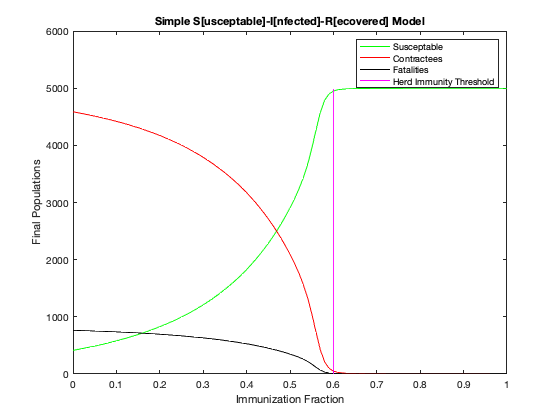

```matlab
%%%%%%%%%%%%%%%%%%%%%%%%%%%%%%%%%%%%%%%%%%%%%%%%%%%%%%%%%%%%%%%%%%%%%%%%%%%
%
% Plotting our Players against Immunity Rate

% that first "figure()" command makes the background color white and gives
%     the graph window a title

figure('Name',  'SIR Model Plot', ...  % that elispis lets you continue
       'Color', 'white')               % a single command on more than one
                                       % line.  Useful when you want to make
                                       % things look pretty or if you just
                                       % have a lot to do in a single
                                       % line command

C_Final = I_final + R_final + F_final; % total number of people who have/had the illness

plot(immunity_rates, S_final, "g-", ...
     immunity_rates, C_Final, "r-", ...
     immunity_rates, F_final, "k-", ...
     [Po Po],[0 max(S_final+C_Final)], "m-");

xlabel('Immunization Fraction');
ylabel('Final Populations');
title('Simple S[usceptable]-I[nfected]-R[ecovered] Model');
legend('Susceptable', ...
       'Contractees', ...
       'Fatalities',  ...
       'Herd Immunity Threshold');
```

## A few things to try.

1. Simulate a nastier disease (or a more gentle one) and try to combine the terms to have a very high (or low Ro).
2. Try to change the number of players to start off with who enter the game ill.
3. Change behavior of Sick or Well people when they become ill. Because being sick cramps your social life.
4. Chagne the immunity rate for various levels to demonstrate herd immunity.

Have fun! (and get your flu shot!).